# Stat 405 Mortality

November 23, 2022

## Data

## Data Introduction

- Gathered from the National Bureau of Economic Research, who creates and distributes a dataset of US mortality for every year since 1959
- Each row represents a single death, while each column represents a different demographic characteristic of the deceased.
- Used the 2019 edition of the dataset since we did not want to focus on COVID-19
- Important information includes education, sex, age classification, day of month, place of death, weekday, manner of death, cause of death, and different - risk factors for each deceased individual

## Secondary Dataset

- Using Behavioral Risk Factor Surveillance System Survey
- Includes different free text survey questions from across the United States and territories with responses broken out by subgroup
  - Includes questions on demographic characteristics, plus queries on current health behaviors, such as tobacco use and seatbelt use
- Combined the secondary dataset by matching up subgroups between the death dataset and the risk factor dataset
  - Tried to use aggregate statistics to analyze how risk factors can be matched with causes of death.

## Questions

## Given someone is dead, how did they die?

## Hypothesis + More Questions

## Exploration & Methods

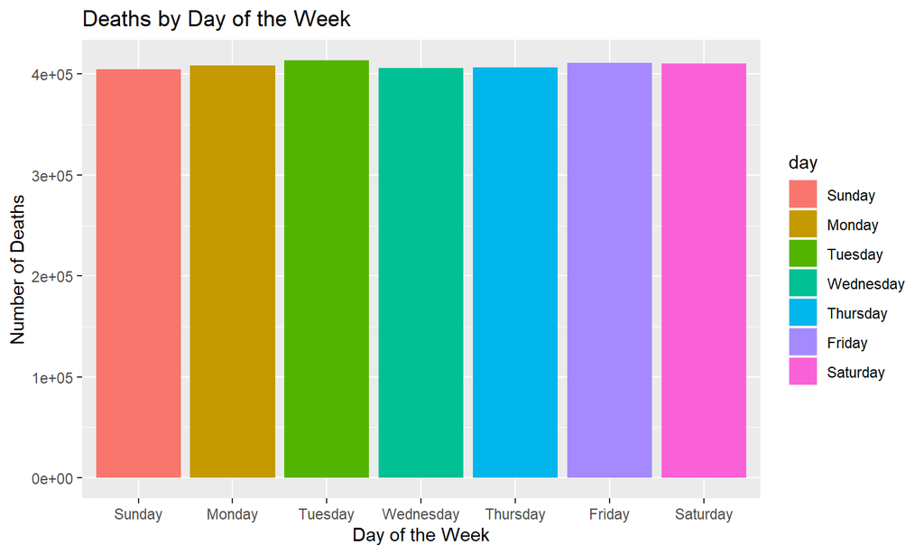

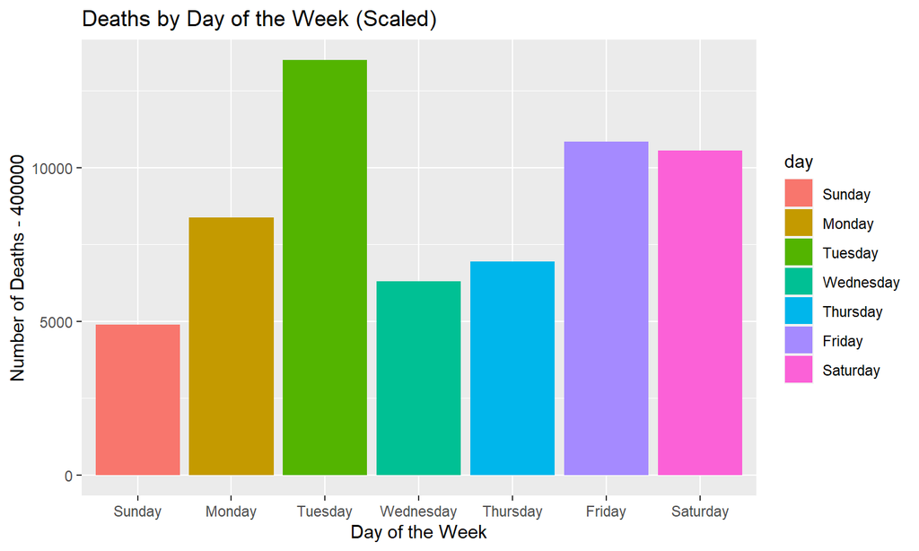

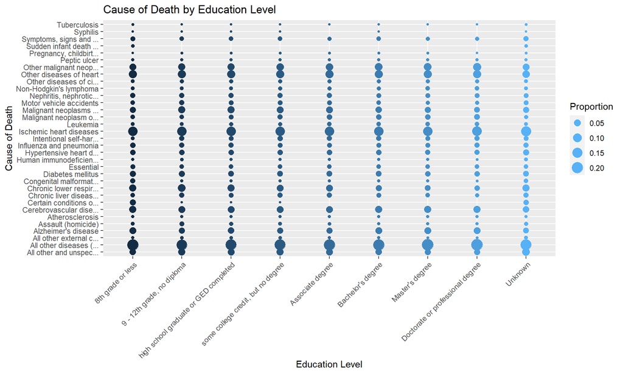

## Table

| cause | 8th grade or less | 9 - 12th grade, no diploma | Associate degree | Bachelor’s degree | Doctorate or professional degree | high school graduate or GED completed | Master’s degree | some college credit, but no degree | Unknown |
| --- | --- | --- | --- | --- | --- | --- | --- | --- | --- |
| Alzheimer’s disease | 0.0501966 | 0.0358828 | 0.0382503 | 0.0475508 | 0.0480320 | 0.0423834 | 0.0510434 | 0.0381342 | 0.0286979 |
| Assault (homicide) | 0.0059129 | 0.0161088 | 0.0038841 | 0.0022317 | 0.0014330 | 0.0072094 | 0.0018295 | 0.0059730 | 0.0076438 |
| Atherosclerosis | 0.0017687 | 0.0014094 | 0.0012893 | 0.0015848 | 0.0017679 | 0.0015421 | 0.0015769 | 0.0015382 | 0.0016092 |
| Influenza and pneumonia | 0.0219389 | 0.0179379 | 0.0160672 | 0.0162589 | 0.0178096 | 0.0173171 | 0.0163816 | 0.0158468 | 0.0197130 |
| Leukemia | 0.0064566 | 0.0058755 | 0.0097400 | 0.0110452 | 0.0129525 | 0.0073617 | 0.0117504 | 0.0087811 | 0.0047510 |
| Sudden infant death syndrome | 0.0041554 | NA | NA | NA | NA | NA | NA | NA | 0.0025863 |

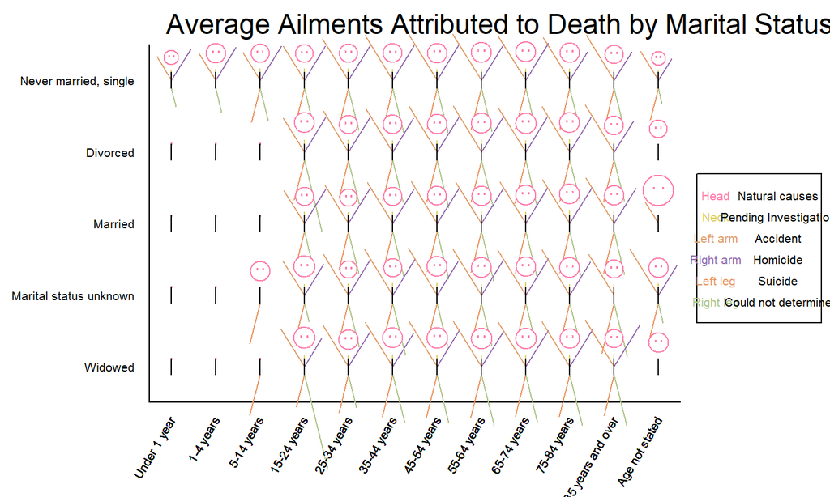

## Analysis

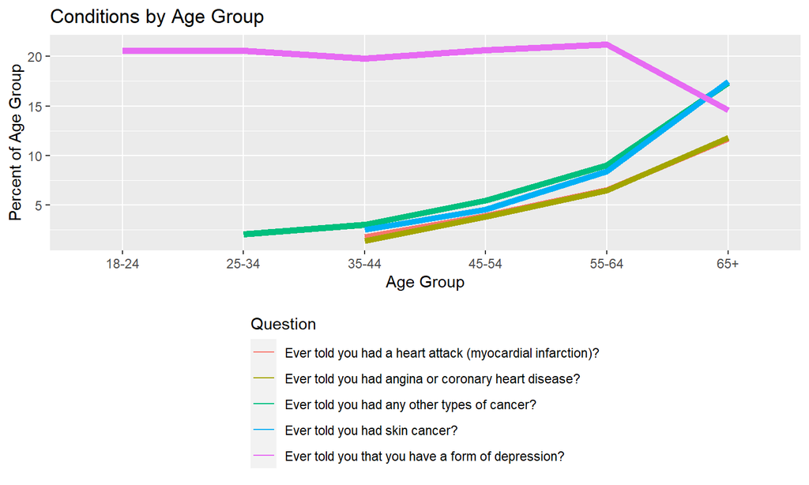

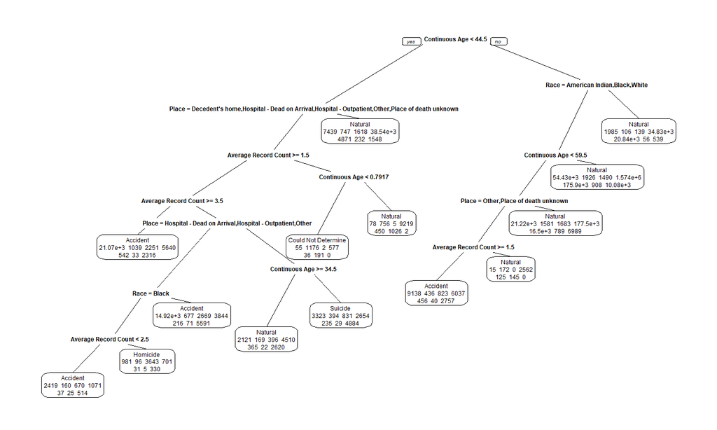

Decision Tree

0.8301203%